# Semana 6 - Regresion Lineal Simple II

Mariano Prado

26 setiembre, 2025

Trabajaremos con datos que corresponden a tres variables medidas en 20 personas que se encuentran en un programa de salud: edad, peso y cantidad de grasa en la sangre. Los datos son:

```r
edad  <- c(46,20,52,30,57,25,28,36,57,44,24,31,52,23,60,48,34,51,40,34)
peso  <- c(84,73,65,70,76,69,63,72,79,75,27,89,65,57,59,69,60,79,75,82)
grasa <- c(354,190,405,263,451,302,288,325,402,365,209,290,346,254,395,434,220,374,308,220)
```

```r
datos <- data.frame(edad, peso, grasa)
datos
```

| edad | peso | grasa |
| --- | --- | --- |
| 46 | 84 | 354 |
| 20 | 73 | 190 |
| 52 | 65 | 405 |
| 30 | 70 | 263 |
| 57 | 76 | 451 |
| 25 | 69 | 302 |
| 28 | 63 | 288 |
| 36 | 72 | 325 |
| 57 | 79 | 402 |
| 44 | 75 | 365 |

[output cut: 10 more lines]

```r
#file.choose()
```

“G:\.shortcut-targets-by-id\13fB-Mc1GsOvFewbjZfihN78KKpjc-oG1\1. Clases en UTEC\Estadistica y Probabilidades 2025-2\Grupo 6\datos.csv”

```r
# Guardar el data frame como archivo csv

write.csv(datos, file = "G:\\.shortcut-targets-by-id\\13fB-Mc1GsOvFewbjZfihN78KKpjc-oG1\\1. Clases en UTEC\\Estadistica y Probabilidades 2025-2\\Grupo 6\\datos.csv", row.names = FALSE)
```

```r
library(readr)

# Cargar los datos desde un CSV
data_csv <- read_csv(file = "G:\\.shortcut-targets-by-id\\13fB-Mc1GsOvFewbjZfihN78KKpjc-oG1\\1. Clases en UTEC\\Estadistica y Probabilidades 2025-2\\Grupo 6\\datos.csv")
data_csv
```

| edad | peso | grasa |
| --- | --- | --- |
| 46 | 84 | 354 |
| 20 | 73 | 190 |
| 52 | 65 | 405 |
| 30 | 70 | 263 |
| 57 | 76 | 451 |
| 25 | 69 | 302 |
| 28 | 63 | 288 |
| 36 | 72 | 325 |
| 57 | 79 | 402 |
| 44 | 75 | 365 |

[output cut: 10 more lines]

Antes de realizar cualquier proceso de regresión, debemos conocer la relación existente entre cada par de variables, para poder concluir si vale la pena o no calcular un modelo de regresión.

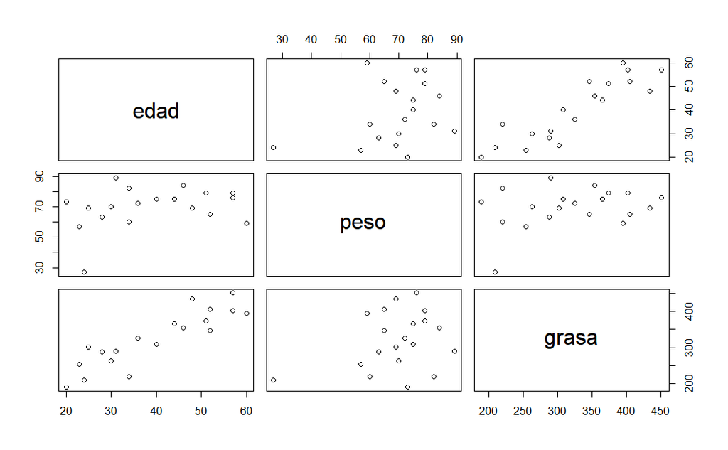

```r
pairs(data_csv)
```

Para cuantificar el grado de asociación lineal, calculamos el coeficiente de correlación lienal, el cual, cuando se tiene más de dos variables, se puede calcular como la matriz de coeficientes de correlación.

```r
cor(data_csv)
```

```
           edad      peso     grasa
edad  1.0000000 0.2705334 0.8741798
peso  0.2705334 1.0000000 0.3009460
grasa 0.8741798 0.3009460 1.0000000
```

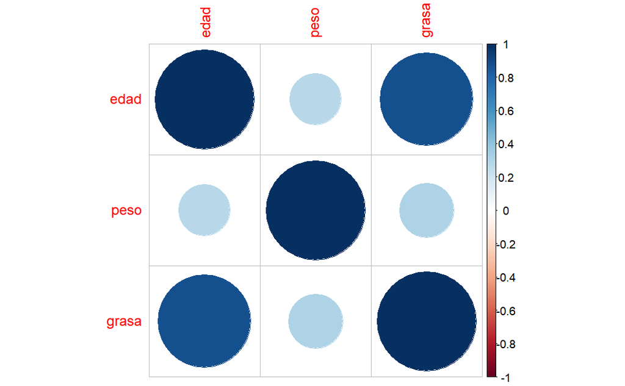

```r
library(corrplot)
corrplot(cor(data_csv))
```

Variable Y: Grasa Variable X: Edad

$$Grasa = f(Edad)$$

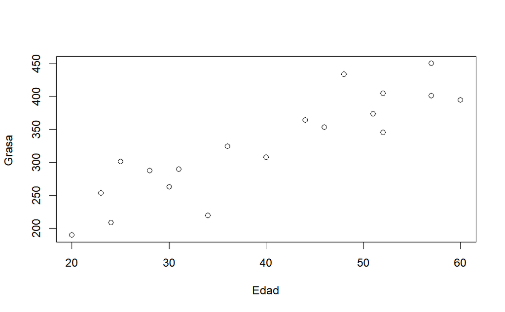

```r
plot(data_csv$edad, data_csv$grasa,
     xlab = "Edad",
     ylab = "Grasa ",

     )
```

```r
modelo <- lm(data_csv$grasa ~ data_csv$edad)
summary(modelo)
```

```
Call:
lm(formula = data_csv$grasa ~ data_csv$edad)

Residuals:
   Min     1Q Median     3Q    Max
-69.75 -25.37  -2.68  23.51  69.25

Coefficients:
              Estimate Std. Error t value    Pr(>|t|)
(Intercept)   107.6328    29.1057   3.698     0.00165 **
data_csv$edad   5.3565     0.7013   7.638 0.000000471 ***
---
Signif. codes:  0 ‘***’ 0.001 ‘**’ 0.01 ‘*’ 0.05 ‘.’ 0.1 ‘ ’ 1

Residual standard error: 38.94 on 18 degrees of freedom
Multiple R-squared:  0.7642,    Adjusted R-squared:  0.7511
F-statistic: 58.33 on 1 and 18 DF,  p-value: 0.0000004712
```

$R^2$ = 0.7642. El 76.42% de la variación de la grasa en sangre es explicado por la variable Edad.

Variable Y: Grasa Variable X: Edad

**El modelo de regresión lineal simple**

$$Y = 107.6328 + 5.3565 X$$

**Grafica de los datos y el modelo generado**

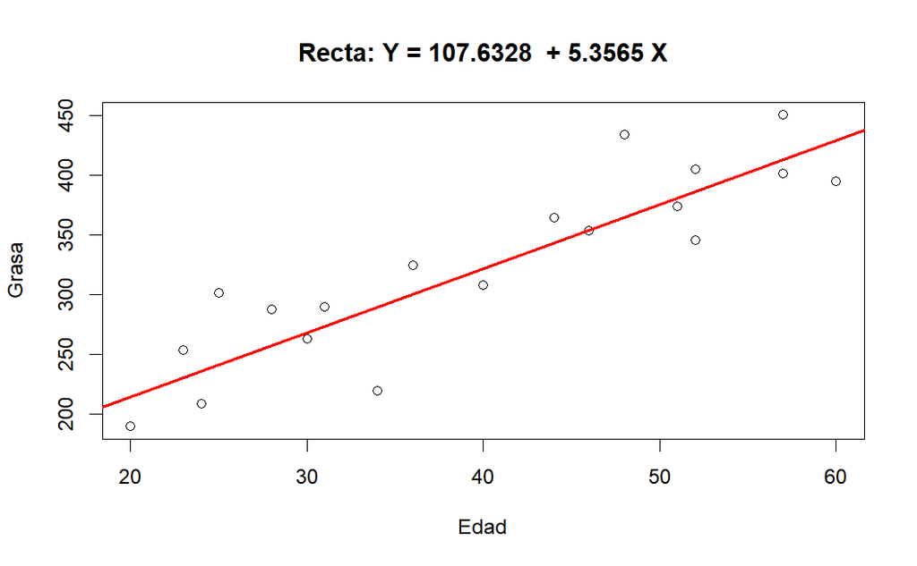

```r
plot(data_csv$edad, data_csv$grasa
    ,ylab = "Grasa"
    ,xlab = "Edad"
    ,main = "Recta: Y = 107.6328  + 5.3565 X" )

abline(modelo  # Agrega la recta
        ,col = "red"
        ,lwd = 2)
```

```r
modelo
```

```
Call:
lm(formula = data_csv$grasa ~ data_csv$edad)

Coefficients:
  (Intercept)  data_csv$edad
      107.633          5.356
```

$\beta_0$: 107.633, la cantidad de grasa en sangre es de 107.633 cuando la persona tiene cero años. $\beta_1$: 5.356, indica que la cantidad de grasa en sangre aumenta en 5.356 cuando la persona incrementa su edad en 1 año. q

** Analisis de los Errores**

```r
grasa_predecido = predict(modelo) # Los valores de Y que están en la recta
Error = data_csv$grasa - grasa_predecido
data.frame(edad = data_csv$edad
           ,grasa = data_csv$grasa
           ,grasa_predecido
           ,Error)
```

|  | edad | grasa | grasa_predecido | Error |
| --- | --- | --- | --- | --- |
| 1 | 46 | 354 | 354.0316 | -0.03156222 |
| 2 | 20 | 190 | 214.7627 | -24.76271571 |
| 3 | 52 | 405 | 386.1705 | 18.82947321 |
| 4 | 30 | 263 | 268.3277 | -5.32765668 |
| 5 | 57 | 451 | 412.9530 | 38.04700272 |
| 6 | 25 | 302 | 241.5452 | 60.45481381 |
| 7 | 28 | 288 | 257.6147 | 30.38533152 |
| 8 | 36 | 325 | 300.4666 | 24.53337875 |
| 9 | 57 | 402 | 412.9530 | -10.95299728 |
| 10 | 44 | 365 | 343.3186 | 21.68142598 |

[output cut: 10 more lines]

```r
options(scipen = 999) #Elimina la notación científica decimal
sum(Error)
```

```
[1] 0.000000000003183231
```

** Predicción con nuevos datos **

```r
# Llamar los coeficientes del modelo
modelo
```

```
Call:
lm(formula = data_csv$grasa ~ data_csv$edad)

Coefficients:
  (Intercept)  data_csv$edad
      107.633          5.356
```

PREDICCIÓN

¿Cuando una persona tiene 80 años que cantidad de grasa tendría?

```r
107.632834 + 5.356494 * (80)
```

[output not shown]